# Week 1: Review!

PS 813 - Causal Inference

Anton Strezhnev

strezhnev@wisc.edu

University of Wisconsin-Madison

January 20, 2027

## Welcome!

$$\require{cancel}$$

## Course Overview

- Instructor: **Anton Strezhnev**
- TA: **Junda Li**
- Logistics:
  - **Lectures** M/W - 9:30am - 10:45am
  - *5* Problem Sets (~ 2 weeks)
  - In-class midterm (March 4th)
  - In-class final (May 4th)
  - **My office hours:** Tuesdays 2pm-4pm (North Hall 322D)
  - **Junda’s office hours:** Thursdays, 1:30pm-3:30pm, (North Hall 101/Grad Lounge)
  - **Course Website**: https://www.antonstrezhnev.com/ps813
  - Announcements will be posted on **Ed** - please let me know if you do not have access.

## Course Objectives

- What is this course about?
  - **Defining** causal effects w/ a structured statistical framework (potential outcomes)
  - **Outlining** assumptions necessary to identify causal effects from data
  - **Estimating** and conducting **inference** on causal effects
- Goals for the course
  - Give you the tools you need to develop your own causal research designs and comment on others’ designs.
  - Equip you with an understanding of the fundamentals of causal inference to enable you to learn new methods.
  - Professionalization - how did causal inference emerge as a field and how do different disciplines approach the topic?

## Course workflow

- **Lectures**
  - One set of slides for each of the two lectures in each week
  - Your primary point of instruction - goal is to **synthesize** the core material + give you the tools to learn more.
  - I want lectures to be **interactive** - you should ask questions and interrupt!
  - You should do the readings prior to each week, but definitely be sure to do them before the Wednesday.
- **Readings**
  - Mix of textbooks and papers
  - Combination of “theory” readings w/ selected applications to political science (and sociology/econ)
  - Organized on the syllabus by priority. **Try** to do all of them, but if you need to prioritize, start with the first ones on the list for the week.
  - All readings available digitally on the course website.

## Course workflow

- **Problem sets** (25% of your grade)
  - Main day-to-day component of the class – meant to get you working with your colleagues and thinking hard about the material.
  - Collaboration is **strongly encouraged** – you should ask and answer questions on our class **Ed Discussion** board
  - Submit on the **Gradescope** assignment platform
  - Grading is on a **plus/check/minus** scale.
    - Conversion to grade point is somewhat holistic.
    - Majority plusses is an A, Majority checks is an AB, Majority minus is a B
  - Solutions will be posted after the due-date.

## Course workflow

- **Midterm Exam** (30% of your grade)
  - The midterm will be in-class on March 4th
    - Covers all material up to that point (experiments + selection-on-observables)
    - Combination of theoretical questions and code/results analysis.
- **Final Exam** (35% of your grade)
  - The final exam will be in-person and written during the exam period (May 4th)
  - A longer version of the midterm exam (to cover the 2 hour exam block).
- **Participation** (10% of your grade)
  - It is important that you actively engage with lecture and with the teaching staff – ask and answer questions.
  - Do the reading!
  - Participating on Ed counts towards this as well.

## Class Requirements

- **Overall**: An interest in learning and willingness to ask questions.
- Generally assume some background in probability theory and statistics (e.g. an intro course taught in most departments)
- Main concepts to be familiar with:
  - properties of random variables
  - estimands and estimators
  - bias, variance, consistency
  - central limit theorem
  - confidence intervals; hypothesis testing

## A brief overview

- **Week 1:** Review of the properties of estimators
- **Week 2-4:** Experiments
- **Week 5-7:** Selection-on-observables
- **Week 8:** Instrumental variables
- **Week 9-10:** Differences-in-differences
- **Week 11:** Panel data causal inference
- **Week 12:** Regression discontinuity designs
- **Week 13:** Causal mediation; sensitivity analysis
- **Week 14:** Shift-share designs and experiments with interference

## Review: Estimators and their properties

## Estimation

- One critical use of statistical theory is understanding how to learn about things we **don’t observe** using things that we **do observe**. We call this estimation.
  - What is the share of voters in Wisconsin who will turn out in the 2026 election?
  - What is the share of voters who turn out **among those assigned** to receive a GOTV phone call?
- **Estimand**: The **unobserved** quantity that we want to learn about. Often denoted via a greek letter (e.g. $\mu$, $\pi$)
  - Often a “population” characteristic that we want to learn about via a sample.
    - But in this class, you’ll learn another reason why we sometimes can’t observe a quantity of interest even in a sample!
  - Important to define your estimand well. **(Lundberg, Johnson and Stewart, 2022)**

## Estimation

- **Estimator**: The **function** of random variables that we will use to try to estimate the quantity of interest. Often denoted with a hat on the parameter of interest (e.g. $\hat{\mu}$, $\hat{\pi}$)
  - Why are the variables random?
    - **Classic inference**: We have a random sample from the population - if we took another sample, we would obtain a different realization when applying our estimator to the new sample.
    - **Design-based inference**: We have a randomly assigned treatment - if we were to re-run the experiment, we would observe a different treatment/control difference b/c of different allocation of units.
- **Estimate**: A single realization of our estimator (e.g. 0.3, 9.535)
  - We often report both point estimates (“best guess”) and interval estimates (e.g. confidence intervals).
  - Careful not to confuse properties of estimators with properties of the estimates themselves.

## Estimation

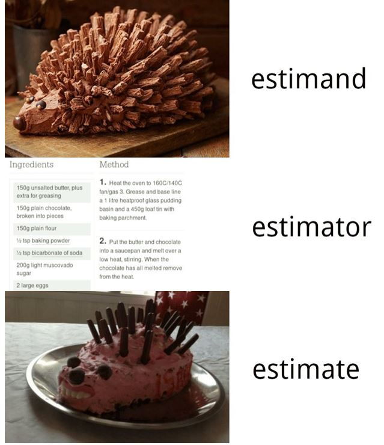

Illustrating Estimation

## Estimation

- The classic estimation problem in statistics is to estimate some unknown population mean $\mu$ from an i.i.d. sample of $n$ observations $Y_1, Y_2, \dotsc, Y_n$.
  - We assume that each $Y_i$ is a draw from the target population with mean $\mu$ and population variance $\sigma^2$ (identically distributed) - therefore $E[Y_i] = \mu$ and $Var(Y_i) = \sigma^2$
  - We’ll also assume that conditioning on $Y_i$ tells us nothing about any other $Y_j$
  - $Y_i \perp \!\!\! \perp Y_j$ (independently distributed) - this implies $Cov(Y_i, Y_j) = 0$
- **Our estimand:** $\mu$
- **Our estimator:** The sample mean $\hat{\mu} = \bar{Y} = \frac{1}{n}\sum_{i=1}^n Y_i$
- **Our estimate:** A particular realization of that estimator based on our observed sample (e.g. $0.4$)
- Note that our estimator is a *random variable* – it’s a function of $Y_i$s which are random variables.
  - Therefore it has an expectation $E[\hat{\mu}]$
  - It has a variance $Var(\hat{\mu})$
  - It has a distribution (which we may or may not know).

## Estimation

- How do we know if we’ve picked a good estimator? Will it be close to the truth? Will it be systematically higher or lower than the target?
- We want to derive some of its properties
  - **Bias**: $E[\hat{\mu}] - \mu$
  - **Variance**: $Var(\hat{\mu})$
  - **Consistency**: Does $\hat{\mu}$ converge in probability to $\mu$ as $n$ goes to infinity?
  - **Asymptotic distribution**: Is the sampling distribution of $\hat{\mu}$ well approximated by a known distribution?

## Estimation

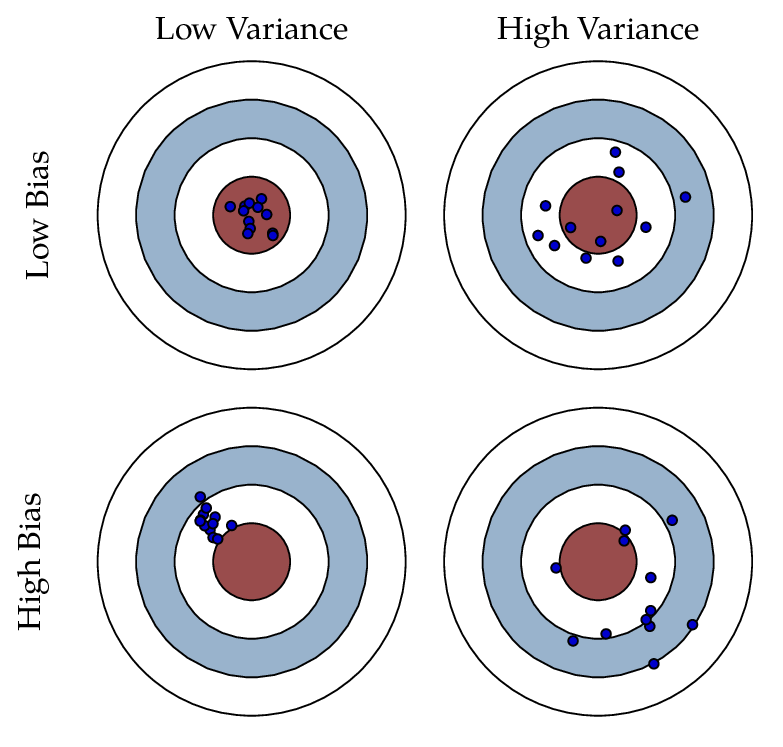

Properties of Estimators

## Unbiasedness

- Is the expectation of $\hat{\mu}$ equal to $\mu$?
- First we pull out the constant.

  $$E[\hat{\mu}] = E\left[\frac{1}{n}\sum_{i=1}^n Y_i\right] = \frac{1}{n}E\left[\sum_{i=1}^n Y_i\right]$$
- Next we use linearity of expectations

  $$\frac{1}{n}E\left[\sum_{i=1}^n Y_i\right] = \frac{1}{n}\sum_{i=1}^n E\left[Y_i\right]$$
- Finally, under our i.i.d. assumption

  $$\frac{1}{n}\sum_{i=1}^n E\left[Y_i\right] = \frac{1}{n}\sum_{i=1}^n \mu = \frac{n \mu}{n} = \mu$$
- Therefore, the bias, $\text{Bias}(\hat{\mu}) = E[\hat{\mu}] - \mu = 0$

## Variance

- What is the variance of $\hat{\mu}$? Again, start by pulling out the constant.

  $$Var(\hat{\mu}) = Var\left[\frac{1}{n}\sum_{i=1}^n Y_i\right] = \frac{1}{n^2}Var\left[\sum_{i=1}^n Y_i\right]$$
- We can further simplify by using our i.i.d. assumption. The variance of a sum of i.i.d. random variables is the sum of the variances.

  $$\frac{1}{n^2}Var\left[\sum_{i=1}^n Y_i\right] = \frac{1}{n^2}\sum_{i=1}^n Var\left[Y_i\right]$$
- “identically distributed”

  $$\frac{1}{n^2}\sum_{i=1}^n Var\left[Y_i\right] = \frac{1}{n^2}\sum_{i=1}^n \sigma^2 = \frac{n\sigma^2}{n^2} = \frac{\sigma^2}{n}$$
- Therefore, the variance is $\frac{\sigma^2}{n}$

## Asymptotic properties

- Another way of talking about properties of estimators is to consider how they **behave** as the sample size gets large.
  - Sometimes this is just *easier* than working with finite sample expectations.
  - Additionally, we might have a **biased** estimator. Does that bias “go away” in large samples?
- This requires us to talk about **sequences** of estimators indexed (typically) by sample size.
  - We’ll typically denote this sequence with a subscript - for example, for the sample mean…

  $$\bar{Y}_n = \{\bar{Y}_1, \bar{Y}_2, \bar{Y}_3, \dotsc\}$$
- Can we characterize the **limit** of this sequence of estimators?
  - It’s a **random variable**…so we need a slightly different language compared to deterministic series.
  - But a lot of intuitions from convergence of series carry over!

## Convergence in probability

- First, we can talk about the convergence of a sequence to a single **value**
  - There are lots of different forms of convergence here, but the most common that we use is **convergence in probability**
  - This is the form of convergence in the “weak” law of large numbers
- **Convergence in probability**
  - A sequence of random variables $\hat{\mu}_n$ is said to **converge in probability** to some value $\mu$ if for every $\epsilon > 0$,

    $$\Pr(|\hat{\mu}_n - \mu| \ge \epsilon) \to 0$$
    as $n \to \infty$.
- We’ll denote this as $\hat{\mu_n} \xrightarrow{p} \mu$. You’ll see other texts use the term “plim”
- An **estimator** that converges in probability to the target estimand is called **consistent**.

## Properties of convergence in probability

- Consider two sequences $X_n \xrightarrow{p} x$ and $Y_n \xrightarrow{p} y$ and continuous function $g()$. By the continuous mapping theorem
1. $X_n + Y_n \xrightarrow{p} x + y$
2. $X_nY_n \xrightarrow{p} xy$
3. $X_n/Y_n \xrightarrow{p} x/y$ if $y \neq 0$
4. $g(X_n) \xrightarrow{p} g(x)$

## Convergence in distribution

- In addition to asking whether the estimator will get closer to our target as $n$ gets large, we also want to know whether its **sampling distribution** will be well approximated by a known distribution
  - Specifically, we care about whether it is approximately **normally distributed**
  - This lets us use our typical hypothesis tests and confidence intervals that rely on normal distribution critical values!
- **Convergence in distribution**
  - A sequence of random variables $X_n$ with CDF $F_n(x)$ is said to **converge in distribution** to some random variable $X$ with CDF $F(x)$ if

    $$\lim_{n \to \infty} F_n(x) = F(x)$$
- We’ll typically denote this as as $X_n \xrightarrow{d} X$.

## Properties of convergence in distribution

- In addition to the continuous mapping theorem from before, it is also useful to know **Slutsky’s theorem** which involves one sequence converging in distribution and another converging in probability
- Consider two sequences $X_n \xrightarrow{d} X$ and $Y_n \xrightarrow{p} y$
1. $X_n + Y_n \xrightarrow{d} X + y$
2. $X_nY_n \xrightarrow{d} Xy$
3. $X_n/Y_n \xrightarrow{d} X/y$ if $y \neq 0$

## The Central Limit Theorem

- The most famous convergence in distribution result is the **central limit theorem**
  - The mean of $n$ independent and identically distributed random variables converges in distribution to a **normal distribution**
  - Many other **central limit theorems** under different assumptions on the random variables (e.g. “weak” dependence)
  - Showing that an estimator is **asymptotically normal** often involves showing we can write it in a form that admits one of these CLTs
- By the **central limit theorem**

  $$\sqrt{n}(\hat{\mu}_n - \mu) \xrightarrow{d} \mathcal{N}(0, \sigma^2)$$
- And we’ll use this result to justify our asymptotic **approximation** of the sampling distribution of $\hat{\mu}_n$

  $$\hat{\mu}_n \overset{a}{\sim} \mathcal{N}\bigg(\mu, \frac{\sigma^2}{n}\bigg)$$

## Big-$O_p$ and little-$o_p$ notation

- Sometimes we’ll want to use **shorthand** to characterize the asymptotic behavior of a given term
- Little-$o_p$ notation denotes convergence (in probability) to **zero**
  - $Y_n = o_p(1)$ means $\Pr(|Y_n| \ge \epsilon) \to 0$ as $n \to \infty$
  - e.g. for a consistent estimator, we can write $\hat{\mu}_n = \mu + o_p(1)$
- Big-$O_p$ notation denotes **boundedness** of a sequence as $n \to \infty$
  - $Y_n = O_p(1)$ means that $Pr(|Y_n| > M) < \epsilon$ for sufficiently large $n$

## Big-$O_p$ and little-$o_p$ notation

- The rest of the orders are defined **recursively**
  - So $Y_n = O_p(a_n)$ means that $\frac{Y_n}{a_n} = O_p(1)$
- Useful properties
  - $o_p(1) + o_p(1) = o_p(1)$
  - $o_p(1) + O_p(1) = O_p(1)$
  - $O_p(1)o_p(1) = o_p(1)$
  - If a sequence is $o_p(1)$, it is $O_p(1)$ but not vice-versa.

## $\sqrt{n}$-consistency

- Most common place where you will see Big-$O_p$ notation is in discussion of **convergence rates** of estimators
  - Not just **whether** $\hat{\mu}$ converges to $\mu$, but **how quickly**?
  - This matters for determining whether our approximation is going to be **good quality** in finite samples!
- An estimator $\hat{\mu}_n$ has a convergence rate $r_n \to \infty$ if

  $$r_n(\hat{\mu}_n - \mu) = O_p(1)$$
- This implies that the estimation error $\hat{\mu}_n - \mu$ is $O_p(1/r_n)$ or in other words **bounded** in probability by $1/r_n \to 0$.

## $\sqrt{n}$-consistency

- From the central limit theorem, the most common convergence rate that you’ll encounter is $\sqrt{n}$
  - Slower rates appear in nonparametrics and machine learning and create challenges for inference!
- Suppose the central limit theorem holds w.r.t. $\hat{\mu}_n$ (e.g. it’s the sample mean).

  $$\sqrt{n}(\hat{\mu}_n - \mu) \sim \mathcal{N}(0, \sigma^2)$$
- The variance is **finite**, does not depend on $n$, and the distribution is **normal**
  - So we can always find an $M$ sufficiently large that the probability of observing $|\hat{\mu}_n - \mu|$ greater than that $M$ is less than any arbitrary $\epsilon > 0$.
- And therefore

  $$\sqrt{n}(\hat{\mu}_n - \mu) = O_p(1)$$

## Next week

- **Potential outcomes model**
  - Defining treatment effects as **contrasts** in **counterfactuals**
- **Causal identification**
  - How do we connect something we can observe (e.g. a difference-in-means) to something we **can’t** observe (an average treatment effect)?
  - We need to make assumptions!
  - Every identification assumption imposes some **outside knowledge** on the data-generating process.
- **Randomized experiments**
  - Randomized experiments solve the identification problem (for the sample ATE)
  - What can we get **just** with randomization of treatment?